# Statistical Inference: Project 02

Thiago Veras

July 23, 2015

## Analyzing the ToothGrowth data

#### Overview

The ToothGrowth data is the length of odontoblasts (teeth) in each of 10 guinea pigs at each of three dose levels of Vitamin C (0.5, 1, and 2 mg) with each of two delivery methods (orange juice or ascorbic acid).

#### Setting Workspace

```r
setwd("~/CESAR/BIGDATA/datasciencecoursera/statinference-030/project02")
echo = TRUE
library(ggplot2)
library(datasets)
```

#### Loading Data

```r
data("ToothGrowth")
attach(ToothGrowth)
raw_data <- ToothGrowth
```

#### Performing some basic exploratory data analyses

```r
# Getting the structure of the data
str(raw_data)
```

```
## 'data.frame':    60 obs. of  3 variables:
##  $ len : num  4.2 11.5 7.3 5.8 6.4 10 11.2 11.2 5.2 7 ...
##  $ supp: Factor w/ 2 levels "OJ","VC": 2 2 2 2 2 2 2 2 2 2 ...
##  $ dose: num  0.5 0.5 0.5 0.5 0.5 0.5 0.5 0.5 0.5 0.5 ...
```

- len: Tooth Length
- supp: Supplement = Orange Juice (OJ) or Vitamin C (VC)
- dose: Dose (mg)

The raw data contains 60 observations of these 3 variables.

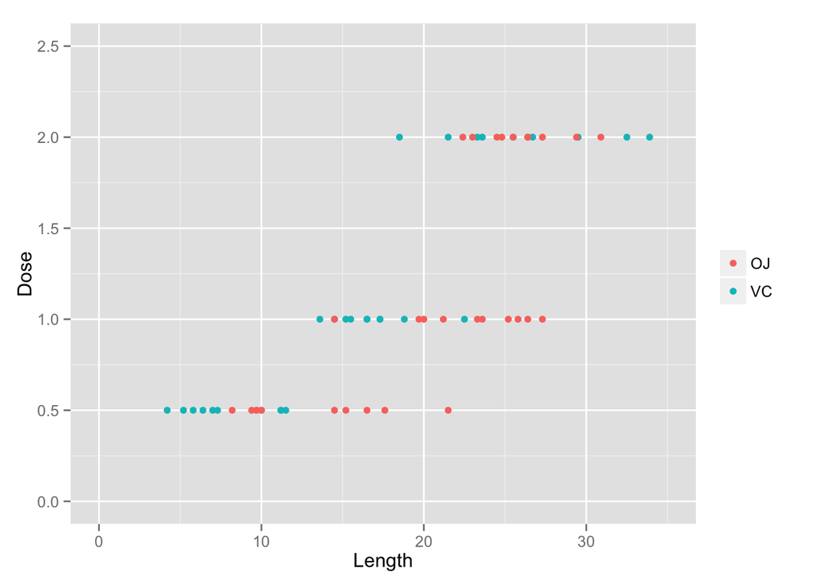

```r
# Plotting the raw data to a basic exploratory data analyses
ggplot(data = raw_data,
       aes(x = len, y = dose, color = supp)) +
       ylim(0,2.5) +
       xlim(0, 35) +
       ylab("Dose") +
       xlab("Length") +
       geom_point() +
       theme(legend.title=element_blank())
```

```r
table(raw_data$dose, raw_data$supp)
```

```
##
##       OJ VC
##   0.5 10 10
##   1   10 10
##   2   10 10
```

#### Providing a basic summary of the data

```r
tooth_data <- raw_data
tooth_data$dose <- factor(tooth_data$dose)
summary(tooth_data)
```

```
##       len        supp     dose
##  Min.   : 4.20   OJ:30   0.5:20
##  1st Qu.:13.07   VC:30   1  :20
##  Median :19.25           2  :20
##  Mean   :18.81
##  3rd Qu.:25.27
##  Max.   :33.90
```

#### Using confidence intervals and T tests to compare tooth growth by supp and dose

##### Comparing tooth growth by supplement

```r
oj_and_vc_dose_0.5mg <- tooth_data[tooth_data$dose==0.5,]
oj_and_vc_dose_1.0mg <- tooth_data[tooth_data$dose==1.0,]
oj_and_vc_dose_2.0mg <- tooth_data[tooth_data$dose==2.0,]

# Testing oranje juice and vitamin c using 0.5 mg
t_test_dose_0.5mg <- t.test(len ~ supp, data=oj_and_vc_dose_0.5mg, var.equal=FALSE)
# Testing oranje juice and vitamin c using 1.0 mg
t_test_dose_1.0mg <- t.test(len ~ supp, data=oj_and_vc_dose_1.0mg, var.equal=FALSE)
# Testing oranje juice and vitamin c using 2.0 mg
t_test_dose_2.0mg <- t.test(len ~ supp, data=oj_and_vc_dose_2.0mg, var.equal=FALSE)
```

Results:  
*oranje juice and vitamin c using 0.5 mg* = [ p-value: *0.006* | confidence interval (-): *1.719* | confidence interval (+): *8.781* ]  
*oranje juice and vitamin c using 1.0 mg* = [ p-value: *0.001* | confidence interval (-): *2.802* | confidence interval (+): *9.058* ]  
*oranje juice and vitamin c using 2.0 mg* = [ p-value: *0.964* | confidence interval (-): *-3.798* | confidence interval (+): *3.638* ]

##### Comparing tooth growth by dose

```r
oj_dose_0.5mg_and_1.0mg <- tooth_data[((tooth_data$dose==0.5 | tooth_data$dose==1.0) & (tooth_data$supp=="OJ")),]
oj_dose_0.5mg_and_2.0mg <- tooth_data[((tooth_data$dose==0.5 | tooth_data$dose==2.0) & (tooth_data$supp=="OJ")),]
oj_dose_1.0mg_and_2.0mg <- tooth_data[((tooth_data$dose==1.0 | tooth_data$dose==2.0) & (tooth_data$supp=="OJ")),]
vc_dose_0.5mg_and_1.0mg <- tooth_data[((tooth_data$dose==0.5 | tooth_data$dose==1.0) & (tooth_data$supp=="VC")),]
vc_dose_0.5mg_and_2.0mg <- tooth_data[((tooth_data$dose==0.5 | tooth_data$dose==2.0) & (tooth_data$supp=="VC")),]
vc_dose_1.0mg_and_2.0mg <- tooth_data[((tooth_data$dose==1.0 | tooth_data$dose==2.0) & (tooth_data$supp=="VC")),]

# Test 0.5 mg and 1.0 mg using orange juice
t_test_oj_dose_0.5mg_and_1.0mg <- t.test(len ~ dose, data=oj_dose_0.5mg_and_1.0mg, var.equal=FALSE)
# Test 0.5 mg and 2.0 mg using orange juice
t_test_oj_dose_0.5mg_and_2.0mg <- t.test(len ~ dose, data=oj_dose_0.5mg_and_2.0mg, var.equal=FALSE)
# Test 1.0 mg and 2.0 mg using orange juice
t_test_oj_dose_1.0mg_and_2.0mg <- t.test(len ~ dose, data=oj_dose_1.0mg_and_2.0mg, var.equal=FALSE)

# Test 0.5 mg and 1.0 mg using vitamin c
t_test_vc_dose_0.5mg_and_1.0mg <- t.test(len ~ dose, data=vc_dose_0.5mg_and_1.0mg, var.equal=FALSE)
# Test 0.5 mg and 2.0 mg using vitamin c
t_test_vc_dose_0.5mg_and_2.0mg <- t.test(len ~ dose, data=vc_dose_0.5mg_and_2.0mg, var.equal=FALSE)
# Test 1.0 mg and 2.0 mg using vitamin c
t_test_vc_dose_1.0mg_and_2.0mg <- t.test(len ~ dose, data=vc_dose_1.0mg_and_2.0mg, var.equal=FALSE)
```

[output not shown]

#### Conclusion

There are clear indications that both the supplement as the dosage have clear indipendent effects on the length of teeth guinea pigs. More those means on avarage longer teeth. Supplement type has a clear influence too, but OJ has a greater avarage teethgrowth in combination with dosages 0.5 and 1 then for the VC supplement, while teeth length for the VC supplement vs the OJ in combiantion with dosage 2 has no significant effect (almost same mean & same confidence interval)

The fact remains however that these assumpionts are based on the facts:

that the guinea pigs are repesentative for the population of guinea pigs, that dosage and supplement were randomly assigned and that the distribution of the means is normal.